# Promise Early Education

### Final Plot 3: Comparing progress of GOLD assessment scores from different ages of the Early Head Start Program (EHS)

We initially started with a specific color palate but changed the colors to a more accessible color pattern. Furthermore, we reordered the bars in each bar graph in numerical order. In these graphs, we focused on how different age groups impacted the weighted average assessment scores for GOLD across various categories. Mathematics, regardless of age, consistently scored the lowest while Physical scored the highest. This relatively similar trend occurred over all three tested age ranges, with only the average values increasing. The graphs were also focused on the time period between three seasons: Fall 2024/2025, Winter 2024/2025, and Spring 2024/2025.

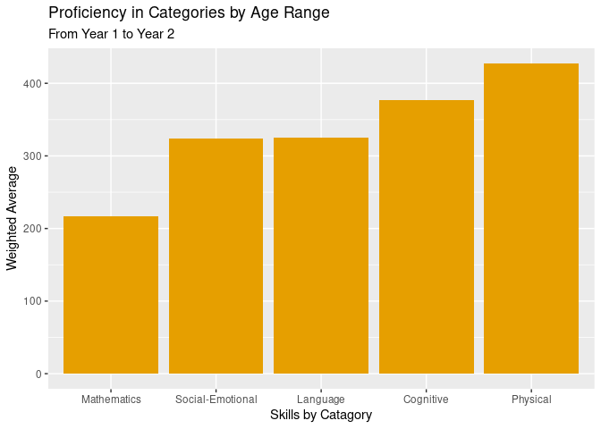

```r
age_one <- EHS_all_students |>
  filter(`age range` == "1-2") |>
  group_by(Category) |>
  summarise(
    Weighted_Average = weighted.mean(Average, `# Children`),
    Children_N = sum(`# Children`),
    .groups = "drop"
  )

ggplot(age_one, aes(x = reorder(Category, Weighted_Average), y = Weighted_Average)) +
  geom_col(fill = "#E69F00") +
  labs(
    title = "Proficiency in Categories by Age Range",
    subtitle = "From Year 1 to Year 2",
    x = "Skills by Catagory",
    y = "Weighted Average"
  )
```

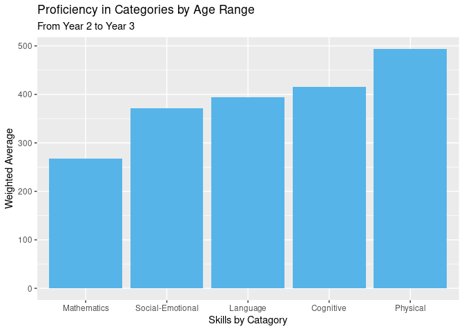

```r
ggsave("ageplot1.png")
age_two <- EHS_all_students |>
  filter(`age range` == "2-3") |>
  group_by(Category) |>
  summarise(
    Weighted_Average = weighted.mean(Average, `# Children`),
    Children_N = sum(`# Children`),
    .groups = "drop"
  )

ggplot(age_two, aes(x = reorder(Category, Weighted_Average), y = Weighted_Average)) +
  geom_col(fill = "#56B4E9") +
  labs(
    title = "Proficiency in Categories by Age Range",
    subtitle = "From Year 2 to Year 3",
    y = "Weighted Average",
    x = "Skills by Catagory"
  )
```

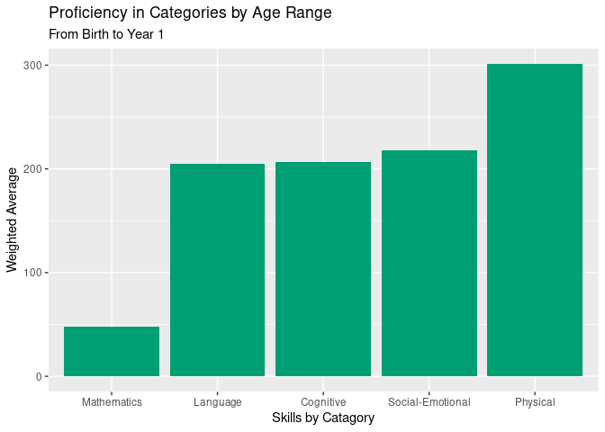

```r
ggsave("ageplot2.png")
age_birth <- EHS_all_students |>
  filter(`age range` == "B-1") |>
  group_by(Category) |>
  summarise(
    Weighted_Average = weighted.mean(Average, `# Children`),
    Children_N = sum(`# Children`),
    .groups = "drop"
  )

ggplot(age_birth, aes(x = reorder(Category, Weighted_Average), y = Weighted_Average)) +
  geom_col(fill = "#009E73") +
  labs(
    title = "Proficiency in Categories by Age Range",
    subtitle = "From Birth to Year 1",
    y = "Weighted Average",
     x = "Skills by Catagory"
  )
```

```r
ggsave("ageplotbirth.png")
```

### Final Plot 4: Comparing GOLD assessment scores of students in the EHS program based on race

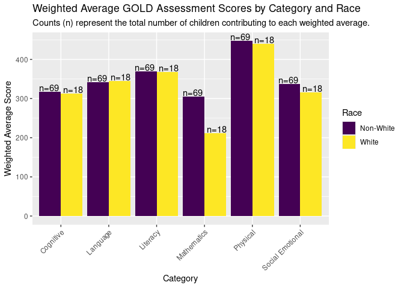

```r
EHS_with_race |>
  mutate(Race_Group = if_else(`White (Yes or No)` == "Yes", "White", "Non-White")) |>
  group_by(Category, Race_Group) |>
  summarise(
    Weighted_Average = sum(Average * `# Children`) / sum(`# Children`),
    Total_Children = sum(`# Children`)
  ) |>
  ggplot(aes(x = Category, y = Weighted_Average, fill = Race_Group)) +
  geom_col(position = position_dodge()) +
  geom_text(
    aes(label = paste0("n=", Total_Children)),
    position = position_dodge(width = 1),
    vjust = -0.1
  ) +
  scale_fill_viridis_d()+
  labs(
    title = "Weighted Average GOLD Assessment Scores by Category and Race",
    subtitle = "Counts (n) represent the total number of children contributing to each weighted average.",
    x = "Category",
    y = "Weighted Average Score",
    fill = "Race"
  ) +
  theme(axis.text.x = element_text(angle = 45, hjust = 1))
```

```r
ggsave("raceplot.png")
```